# DEPENDENCY PARSING PRACTICAL - 5

### Ashish Patidar

For this practical, UD_English_EWT dataset is used. The evaluation metrics of the model is given below:

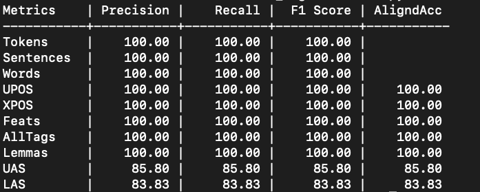

Based on the metrics we can see that for the given corpus this udpipe parser works really well, and we have a UAS F1 score of 85.8, and LAS F1 score of 83.83. To test this parser manually, first 10 sentences of the file were evaluated and there are some mistakes which our udpipe parser is making.

- sentence 1: Morphed is parsed as a verb but it is actually a noun.
- sentence 2: Full is an adjective but is tagged as an adverb.
- sentence 3: Parsed Correctly
- sentence 4: else is an adverb but is parsed as an adjective.
  - sentence 4: nostalgic is tagged as a noun but is an adjective.
- sentence 5: all is parsed as an adverb but it is a determinant.
- sentence 6: Parsed Correctly
- sentence 7: else is incorrectly tagged as an adjective but it is an adverb.
- Rest all three sentences were parsed correctly.